# Liligo Test 2: Paris, France Airbnb

Robert Herczeg

2017-05-14

# Data source

Data was downloaded from [Inside Airbnb](http://insideairbnb.com/get-the-data.html). 3 files were downloaded:

- listings.csv.gz
- reviews.csv.gz
- calendar.csv.gz

Listings contains detailed data about the accommodations such as host name, price, different kinds of score etc.

Reviews data includes the review, the date, the reviewer name etc.

In the calendar data set, we can check the availabilty of given accommodation in a given day.

# Dataset - basic info

# Room type

There are **56,535** locations and ** 85.84% ** of them are entire homes/apartments.

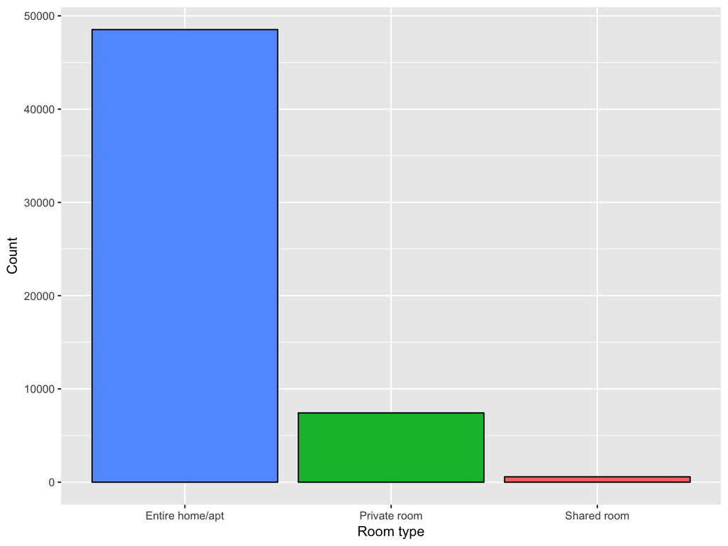

13.14% are Private rooms, while 1.02% are Shared rooms.

# Room type - price (mean, median)

**Entire home/apt** are the **most expensive** compared to the other two types.

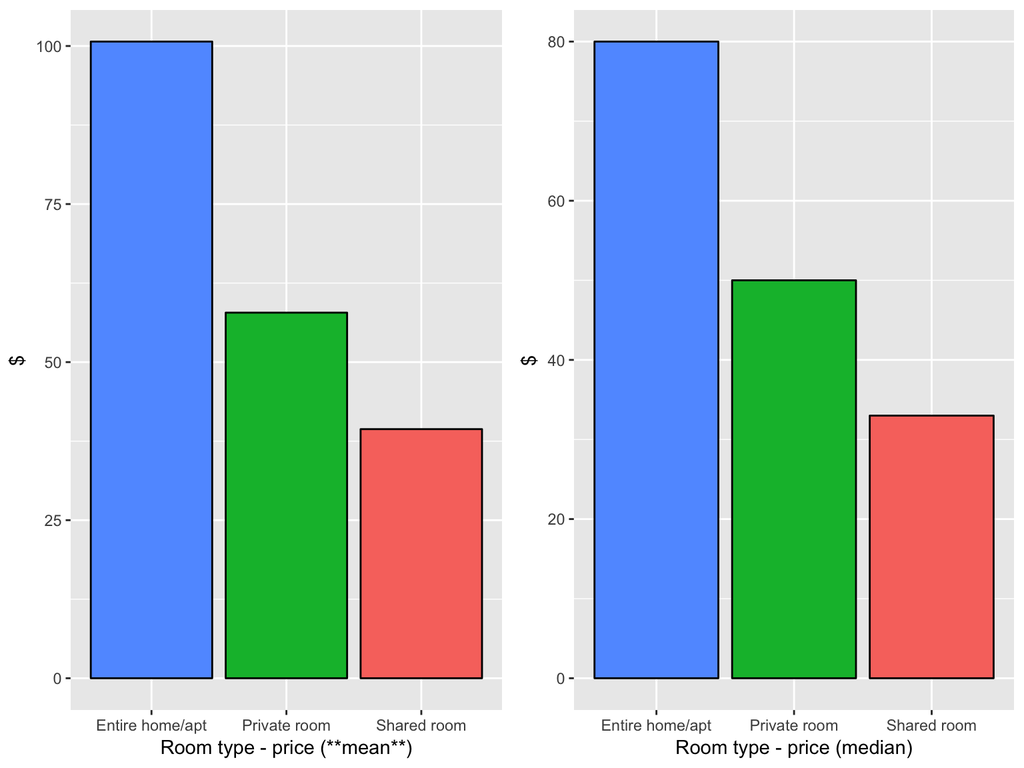

# Distribution of bedrooms

Most of the accommodations have **less than 2 bedrooms**.

[interactive chart not shown]

red >= 3; blue = 2; yellow < 2

# WordCloud

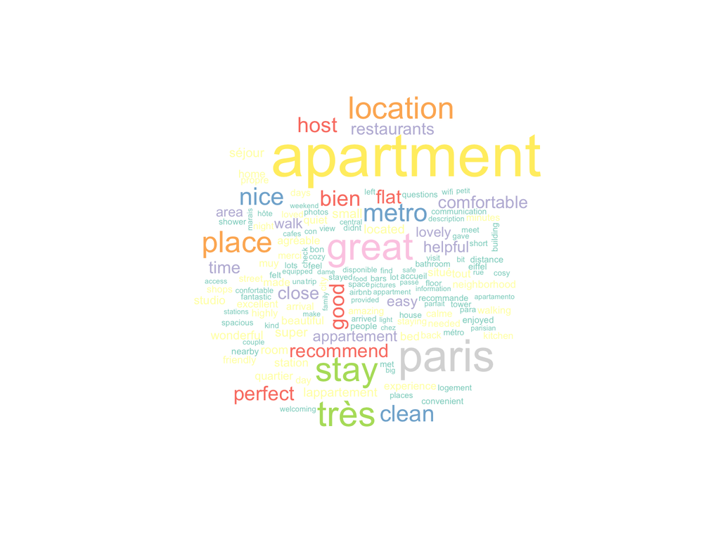

Usually, the most frequent words are **positive**. Based on 3000 random comments from reviews.

# Review tendency over time

[interactive chart not shown]

The number of reviews is continuously **increasing** since the beginning.

# Review prediction - 1

The prediction shows a **growing tendency** which continues in 2018.

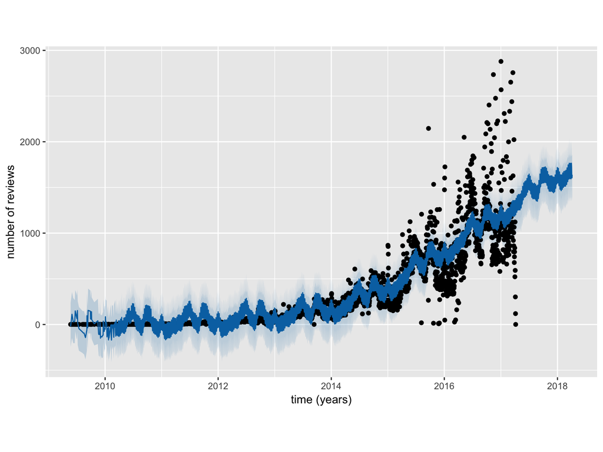

Based on Facebook’s prophet package.